# Prolactin and its receptor: H-P-C gene expression analyses

Victoria

1/9/2019

### Crop sac qPCR data

Some notes on this dataset: Genes-of-interest PRL and PRLR were run in *duplicate* for each crop sample, along with two reference genes, ACTB and rpL4. Gene expression was normalized (dCT) by subtracting the geometric mean of the reference gene duplicates (ACTB and rpL4) from the average Ct of the duplicates for each gene-of-interest.  
*The more positive the dCT, the lower the gene expression relative to reference genes (within a sample)*  
*Can also think of it as “distance from reference gene”*  
The second normalization (ddCT) involved subtracting the average normalized expression (dCT) of the control group (here, **building**) from each normalized sample for that gene. *More positive numbers imply lower expression than average, more negative numbers imply higher expression than average.*  
*For this reason, it is easier to interpret the -ddCT. Now, postive numbers on -ddCT imply higher expression than average control group, and negative numbers imply lower expression than average control group, as one would expect*  
Lowest numbers have lowest relative expression, highest numbers have highest relative expression.

# Hypothalamus

Transcriptomic data from RNAseq.  
##Data distribution  
*Note: “Focal data” refers to data from only the five stages we are interested in: bldg, inc d3, inc d9, m.inc d8, and hatch“*  
Histograms of log transformed data show  
HYP PRL: possible bimodal distribution,  
HYP PRLR: relatively normal distributon

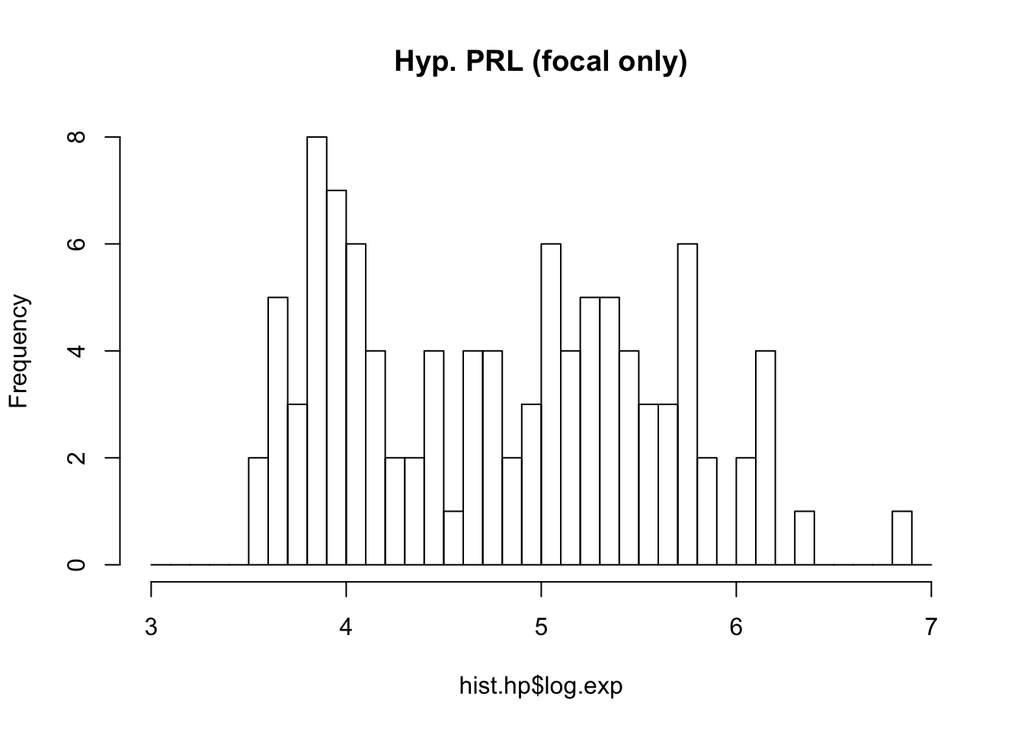

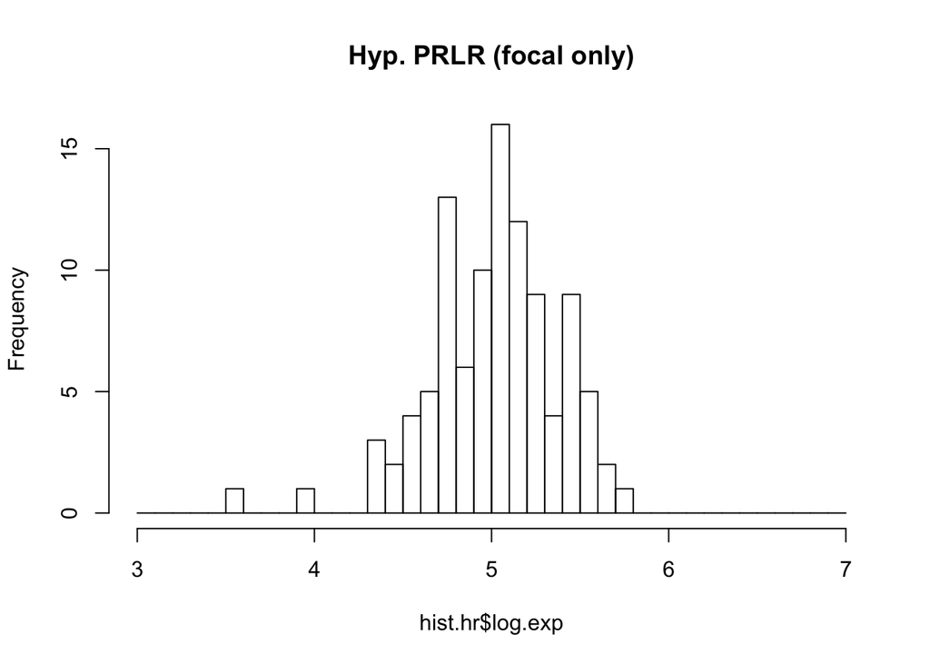

## Gene expression plots

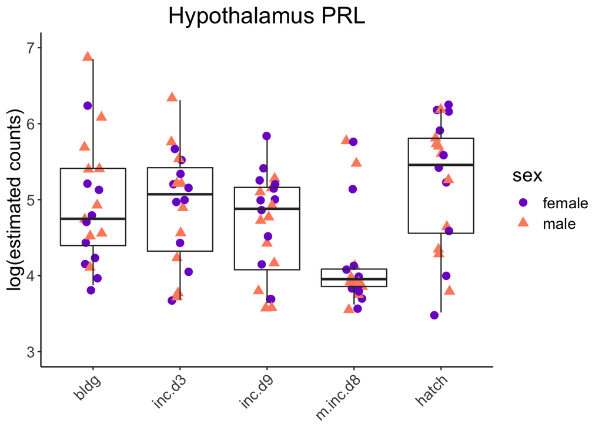

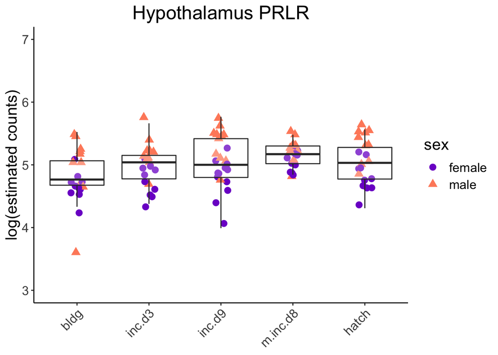

```
## Analysis of Deviance Table
##
## Model: gaussian, link: identity
##
## Response: log.exp
##
## Terms added sequentially (first to last)
##
##
##           Df Deviance Resid. Df Resid. Dev  Pr(>Chi)
## NULL                        102     65.547
## stage      4  11.0749        98     54.472 0.0005504 ***
## sex        1   0.0376        97     54.434 0.7954959
## stage:sex  4   2.3786        93     52.056 0.3732991
## ---
## Signif. codes:  0 '***' 0.001 '**' 0.01 '*' 0.05 '.' 0.1 ' ' 1
```

```
##
## Call:
## glm(formula = log.exp ~ stage * sex, family = "gaussian", data = hprl)
##
## Deviance Residuals:
##     Min       1Q   Median       3Q      Max
## -1.7615  -0.5270   0.0383   0.5202   1.6190
##
## Coefficients:
##                       Estimate Std. Error t value Pr(>|t|)
## (Intercept)             4.6273     0.2366  19.559   <2e-16 ***
## stageinc.d3             0.2620     0.3346   0.783   0.4356
## stageinc.d9             0.1768     0.3203   0.552   0.5824
## stagem.inc.d8          -0.4064     0.3346  -1.215   0.2276
## stagehatch              0.6496     0.3346   1.942   0.0552 .
## sexmale                 0.6043     0.3346   1.806   0.0741 .
## stageinc.d3:sexmale    -0.5610     0.4732  -1.186   0.2388
## stageinc.d9:sexmale    -0.9023     0.4577  -1.972   0.0516 .
## stagem.inc.d8:sexmale  -0.5941     0.4732  -1.255   0.2125
## stagehatch:sexmale     -0.7232     0.4732  -1.528   0.1298
## ---
## Signif. codes:  0 '***' 0.001 '**' 0.01 '*' 0.05 '.' 0.1 ' ' 1
##
## (Dispersion parameter for gaussian family taken to be 0.5597399)
##
##     Null deviance: 65.547  on 102  degrees of freedom
## Residual deviance: 52.056  on  93  degrees of freedom
## AIC: 244.01
##
## Number of Fisher Scoring iterations: 2
```

```
##
## Call:
## glm(formula = log.exp ~ stage * sex, family = "gaussian", data = hprl)
##
## Deviance Residuals:
##     Min       1Q   Median       3Q      Max
## -1.7615  -0.5270   0.0383   0.5202   1.6190
##
## Coefficients:
##                       Estimate Std. Error t value Pr(>|t|)
## (Intercept)            4.88930    0.23659  20.666   <2e-16 ***
## stagebldg             -0.26199    0.33459  -0.783   0.4356
## stageinc.d9           -0.08520    0.32034  -0.266   0.7909
## stagem.inc.d8         -0.66839    0.33459  -1.998   0.0487 *
## stagehatch             0.38762    0.33459   1.159   0.2496
## sexmale                0.04324    0.33459   0.129   0.8974
## stagebldg:sexmale      0.56104    0.47318   1.186   0.2388
## stageinc.d9:sexmale   -0.34130    0.45769  -0.746   0.4577
## stagem.inc.d8:sexmale -0.03302    0.47318  -0.070   0.9445
## stagehatch:sexmale    -0.16211    0.47318  -0.343   0.7327
## ---
## Signif. codes:  0 '***' 0.001 '**' 0.01 '*' 0.05 '.' 0.1 ' ' 1
##
## (Dispersion parameter for gaussian family taken to be 0.5597399)
##
##     Null deviance: 65.547  on 102  degrees of freedom
## Residual deviance: 52.056  on  93  degrees of freedom
## AIC: 244.01
##
## Number of Fisher Scoring iterations: 2
```

```
##
## Call:
## glm(formula = log.exp ~ stage * sex, family = "gaussian", data = hprl)
##
## Deviance Residuals:
##     Min       1Q   Median       3Q      Max
## -1.7615  -0.5270   0.0383   0.5202   1.6190
##
## Coefficients:
##                       Estimate Std. Error t value Pr(>|t|)
## (Intercept)             4.8041     0.2160  22.244   <2e-16 ***
## stageinc.d3             0.0852     0.3203   0.266   0.7909
## stagebldg              -0.1768     0.3203  -0.552   0.5824
## stagem.inc.d8          -0.5832     0.3203  -1.821   0.0719 .
## stagehatch              0.4728     0.3203   1.476   0.1433
## sexmale                -0.2981     0.3123  -0.954   0.3424
## stageinc.d3:sexmale     0.3413     0.4577   0.746   0.4577
## stagebldg:sexmale       0.9023     0.4577   1.972   0.0516 .
## stagem.inc.d8:sexmale   0.3083     0.4577   0.674   0.5023
## stagehatch:sexmale      0.1792     0.4577   0.392   0.6963
## ---
## Signif. codes:  0 '***' 0.001 '**' 0.01 '*' 0.05 '.' 0.1 ' ' 1
##
## (Dispersion parameter for gaussian family taken to be 0.5597399)
##
##     Null deviance: 65.547  on 102  degrees of freedom
## Residual deviance: 52.056  on  93  degrees of freedom
## AIC: 244.01
##
## Number of Fisher Scoring iterations: 2
```

```
##
## Call:
## glm(formula = log.exp ~ stage * sex, family = "gaussian", data = hprl)
##
## Deviance Residuals:
##     Min       1Q   Median       3Q      Max
## -1.7615  -0.5270   0.0383   0.5202   1.6190
##
## Coefficients:
##                       Estimate Std. Error t value Pr(>|t|)
## (Intercept)             5.2769     0.2366  22.304  < 2e-16 ***
## stageinc.d9            -0.4728     0.3203  -1.476  0.14332
## stageinc.d3            -0.3876     0.3346  -1.159  0.24962
## stagebldg              -0.6496     0.3346  -1.942  0.05522 .
## stagem.inc.d8          -1.0560     0.3346  -3.156  0.00215 **
## sexmale                -0.1189     0.3346  -0.355  0.72318
## stageinc.d9:sexmale    -0.1792     0.4577  -0.392  0.69632
## stageinc.d3:sexmale     0.1621     0.4732   0.343  0.73267
## stagebldg:sexmale       0.7232     0.4732   1.528  0.12983
## stagem.inc.d8:sexmale   0.1291     0.4732   0.273  0.78559
## ---
## Signif. codes:  0 '***' 0.001 '**' 0.01 '*' 0.05 '.' 0.1 ' ' 1
##
## (Dispersion parameter for gaussian family taken to be 0.5597399)
##
##     Null deviance: 65.547  on 102  degrees of freedom
## Residual deviance: 52.056  on  93  degrees of freedom
## AIC: 244.01
##
## Number of Fisher Scoring iterations: 2
```

```
##
## Call:
## glm(formula = log.exp ~ stage * sex, family = "gaussian", data = hprl)
##
## Deviance Residuals:
##     Min       1Q   Median       3Q      Max
## -1.7615  -0.5270   0.0383   0.5202   1.6190
##
## Coefficients:
##                     Estimate Std. Error t value Pr(>|t|)
## (Intercept)          4.22091    0.23659  17.841  < 2e-16 ***
## stagehatch           1.05601    0.33459   3.156  0.00215 **
## stageinc.d9          0.58318    0.32034   1.821  0.07190 .
## stageinc.d3          0.66839    0.33459   1.998  0.04868 *
## stagebldg            0.40640    0.33459   1.215  0.22758
## sexmale              0.01022    0.33459   0.031  0.97569
## stagehatch:sexmale  -0.12909    0.47318  -0.273  0.78559
## stageinc.d9:sexmale -0.30828    0.45769  -0.674  0.50226
## stageinc.d3:sexmale  0.03302    0.47318   0.070  0.94452
## stagebldg:sexmale    0.59406    0.47318   1.255  0.21245
## ---
## Signif. codes:  0 '***' 0.001 '**' 0.01 '*' 0.05 '.' 0.1 ' ' 1
##
## (Dispersion parameter for gaussian family taken to be 0.5597399)
##
##     Null deviance: 65.547  on 102  degrees of freedom
## Residual deviance: 52.056  on  93  degrees of freedom
## AIC: 244.01
##
## Number of Fisher Scoring iterations: 2
```

### GLM: Hyp PRLR

“ANOVA” indicates that there is a significant effect of stage and sex on PRLR expression, but no interaction.  
Manipulation day 8 is significantly higher than bldg, day 3, and day 9, but NOT significantly different from hatch.  
All other stages not signficantly different from each other.  
Significant sex difference, where males > females.

```
## Analysis of Deviance Table
##
## Model: gaussian, link: identity
##
## Response: log.exp
##
## Terms added sequentially (first to last)
##
##
##           Df Deviance Resid. Df Resid. Dev  Pr(>Chi)
## NULL                        102    13.4219
## stage      4   1.3276        98    12.0944  0.003097 **
## sex        1   3.9446        97     8.1497 5.875e-12 ***
## stage:sex  4   0.4054        93     7.7443  0.301015
## ---
## Signif. codes:  0 '***' 0.001 '**' 0.01 '*' 0.05 '.' 0.1 ' ' 1
```

```
##
## Call:
## glm(formula = log.exp ~ stage * sex, family = "gaussian", data = hr)
##
## Deviance Residuals:
##      Min        1Q    Median        3Q       Max
## -1.40370  -0.14806   0.03853   0.18109   0.57153
##
## Coefficients:
##                       Estimate Std. Error t value Pr(>|t|)
## (Intercept)            4.67170    0.09125  51.195  < 2e-16 ***
## stageinc.d3            0.08839    0.12905   0.685  0.49509
## stageinc.d9            0.11787    0.12356   0.954  0.34259
## stagem.inc.d8          0.37607    0.12905   2.914  0.00447 **
## stagehatch             0.15921    0.12905   1.234  0.22043
## sexmale                0.28023    0.12905   2.171  0.03244 *
## stageinc.d3:sexmale    0.14364    0.18251   0.787  0.43326
## stageinc.d9:sexmale    0.27248    0.17653   1.543  0.12611
## stagem.inc.d8:sexmale -0.06871    0.18251  -0.376  0.70742
## stagehatch:sexmale     0.18501    0.18251   1.014  0.31334
## ---
## Signif. codes:  0 '***' 0.001 '**' 0.01 '*' 0.05 '.' 0.1 ' ' 1
##
## (Dispersion parameter for gaussian family taken to be 0.08327188)
##
##     Null deviance: 13.4219  on 102  degrees of freedom
## Residual deviance:  7.7443  on  93  degrees of freedom
## AIC: 47.761
##
## Number of Fisher Scoring iterations: 2
```

```
##
## Call:
## glm(formula = log.exp ~ stage * sex, family = "gaussian", data = hr)
##
## Deviance Residuals:
##      Min        1Q    Median        3Q       Max
## -1.40370  -0.14806   0.03853   0.18109   0.57153
##
## Coefficients:
##                       Estimate Std. Error t value Pr(>|t|)
## (Intercept)            4.76009    0.09125  52.163  < 2e-16 ***
## stagebldg             -0.08839    0.12905  -0.685  0.49509
## stageinc.d9            0.02947    0.12356   0.239  0.81198
## stagem.inc.d8          0.28768    0.12905   2.229  0.02821 *
## stagehatch             0.07082    0.12905   0.549  0.58450
## sexmale                0.42387    0.12905   3.284  0.00144 **
## stagebldg:sexmale     -0.14364    0.18251  -0.787  0.43326
## stageinc.d9:sexmale    0.12884    0.17653   0.730  0.46733
## stagem.inc.d8:sexmale -0.21235    0.18251  -1.164  0.24760
## stagehatch:sexmale     0.04137    0.18251   0.227  0.82116
## ---
## Signif. codes:  0 '***' 0.001 '**' 0.01 '*' 0.05 '.' 0.1 ' ' 1
##
## (Dispersion parameter for gaussian family taken to be 0.08327188)
##
##     Null deviance: 13.4219  on 102  degrees of freedom
## Residual deviance:  7.7443  on  93  degrees of freedom
## AIC: 47.761
##
## Number of Fisher Scoring iterations: 2
```

```
##
## Call:
## glm(formula = log.exp ~ stage * sex, family = "gaussian", data = hr)
##
## Deviance Residuals:
##      Min        1Q    Median        3Q       Max
## -1.40370  -0.14806   0.03853   0.18109   0.57153
##
## Coefficients:
##                       Estimate Std. Error t value Pr(>|t|)
## (Intercept)            4.78957    0.08330  57.496  < 2e-16 ***
## stageinc.d3           -0.02947    0.12356  -0.239   0.8120
## stagebldg             -0.11787    0.12356  -0.954   0.3426
## stagem.inc.d8          0.25821    0.12356   2.090   0.0394 *
## stagehatch             0.04134    0.12356   0.335   0.7387
## sexmale                0.55270    0.12046   4.588 1.39e-05 ***
## stageinc.d3:sexmale   -0.12884    0.17653  -0.730   0.4673
## stagebldg:sexmale     -0.27248    0.17653  -1.543   0.1261
## stagem.inc.d8:sexmale -0.34119    0.17653  -1.933   0.0563 .
## stagehatch:sexmale    -0.08746    0.17653  -0.495   0.6214
## ---
## Signif. codes:  0 '***' 0.001 '**' 0.01 '*' 0.05 '.' 0.1 ' ' 1
##
## (Dispersion parameter for gaussian family taken to be 0.08327188)
##
##     Null deviance: 13.4219  on 102  degrees of freedom
## Residual deviance:  7.7443  on  93  degrees of freedom
## AIC: 47.761
##
## Number of Fisher Scoring iterations: 2
```

```
##
## Call:
## glm(formula = log.exp ~ stage * sex, family = "gaussian", data = hr)
##
## Deviance Residuals:
##      Min        1Q    Median        3Q       Max
## -1.40370  -0.14806   0.03853   0.18109   0.57153
##
## Coefficients:
##                       Estimate Std. Error t value Pr(>|t|)
## (Intercept)            4.83091    0.09125  52.939  < 2e-16 ***
## stageinc.d9           -0.04134    0.12356  -0.335 0.738681
## stageinc.d3           -0.07082    0.12905  -0.549 0.584497
## stagebldg             -0.15921    0.12905  -1.234 0.220430
## stagem.inc.d8          0.21686    0.12905   1.680 0.096229 .
## sexmale                0.46524    0.12905   3.605 0.000504 ***
## stageinc.d9:sexmale    0.08746    0.17653   0.495 0.621445
## stageinc.d3:sexmale   -0.04137    0.18251  -0.227 0.821160
## stagebldg:sexmale     -0.18501    0.18251  -1.014 0.313344
## stagem.inc.d8:sexmale -0.25372    0.18251  -1.390 0.167785
## ---
## Signif. codes:  0 '***' 0.001 '**' 0.01 '*' 0.05 '.' 0.1 ' ' 1
##
## (Dispersion parameter for gaussian family taken to be 0.08327188)
##
##     Null deviance: 13.4219  on 102  degrees of freedom
## Residual deviance:  7.7443  on  93  degrees of freedom
## AIC: 47.761
##
## Number of Fisher Scoring iterations: 2
```

# Pituitary

Transcriptomic data from RNAseq.  
##Data distribution  
Histograms of log transformed data show  
PIT PRL: possible bimodal distribution, w/ one large outlier,  
PIT PRLR: relatively normal distributon

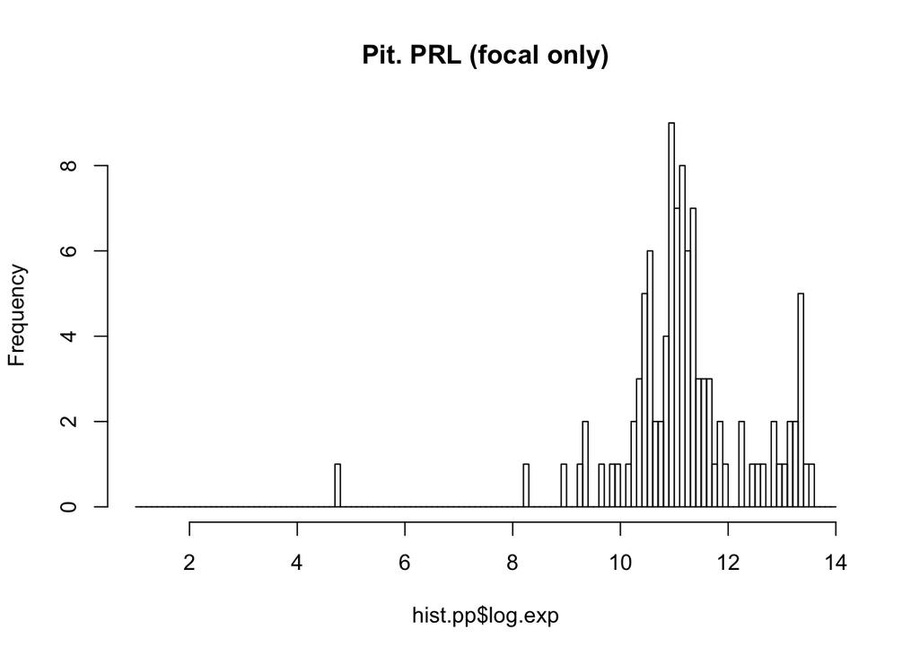

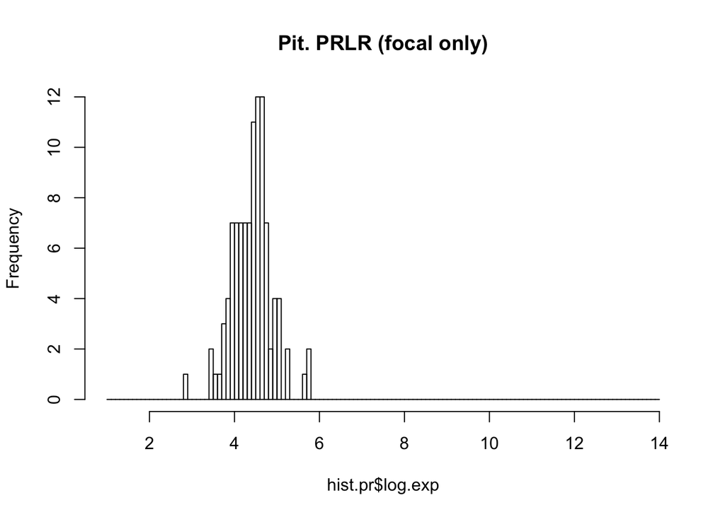

##Gene exp. plots

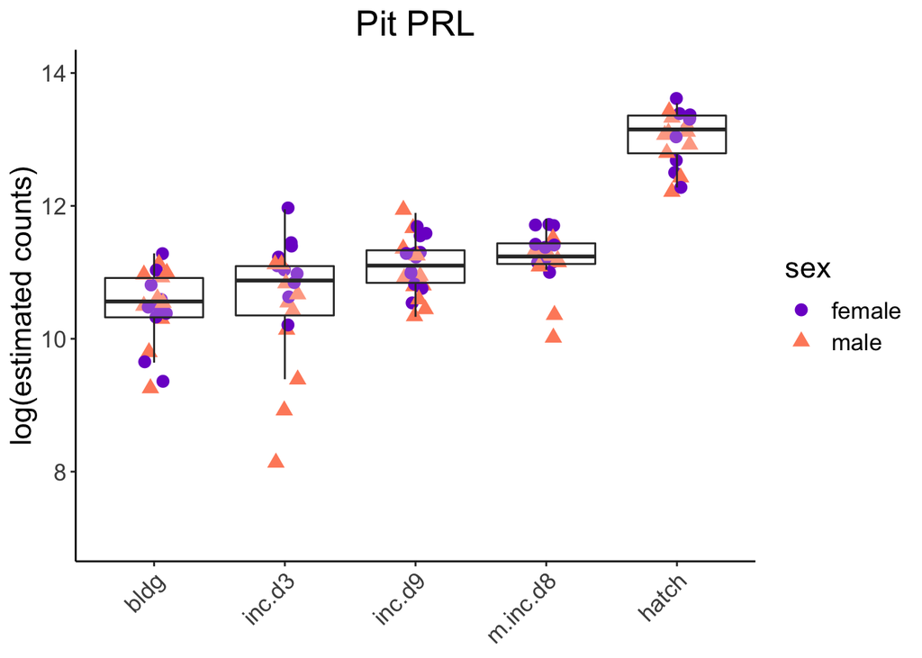

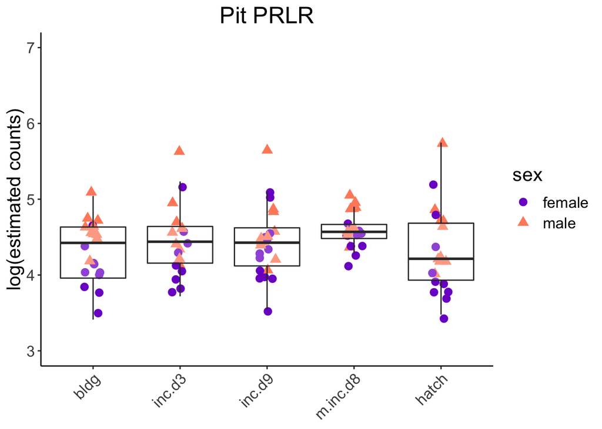

### GLM: Pit PRL

```
## Analysis of Deviance Table
##
## Model: gaussian, link: identity
##
## Response: log.exp
##
## Terms added sequentially (first to last)
##
##
##           Df Deviance Resid. Df Resid. Dev  Pr(>Chi)
## NULL                        103    156.292
## stage      4   86.123        99     70.169 < 2.2e-16 ***
## sex        1    4.733        98     65.437  0.006628 **
## stage:sex  4    5.085        94     60.351  0.094528 .
## ---
## Signif. codes:  0 '***' 0.001 '**' 0.01 '*' 0.05 '.' 0.1 ' ' 1
```

```
##
## Call:
## glm(formula = log.exp ~ stage * sex, family = "gaussian", data = pp)
##
## Deviance Residuals:
##     Min       1Q   Median       3Q      Max
## -5.6093  -0.2270   0.0823   0.3929   1.0524
##
## Coefficients:
##                       Estimate Std. Error t value Pr(>|t|)
## (Intercept)           10.45389    0.25338  41.257  < 2e-16 ***
## stageinc.d3            0.65307    0.35834   1.822  0.07156 .
## stageinc.d9            0.72352    0.33703   2.147  0.03439 *
## stagem.inc.d8          0.94381    0.35834   2.634  0.00987 **
## stagehatch             2.60588    0.35834   7.272 1.04e-10 ***
## sexmale                0.02823    0.35834   0.079  0.93738
## stageinc.d3:sexmale   -0.99299    0.50677  -1.959  0.05302 .
## stageinc.d9:sexmale   -0.21381    0.48596  -0.440  0.66097
## stagem.inc.d8:sexmale -1.02153    0.50677  -2.016  0.04668 *
## stagehatch:sexmale    -0.09398    0.50677  -0.185  0.85327
## ---
## Signif. codes:  0 '***' 0.001 '**' 0.01 '*' 0.05 '.' 0.1 ' ' 1
##
## (Dispersion parameter for gaussian family taken to be 0.6420354)
##
##     Null deviance: 156.292  on 103  degrees of freedom
## Residual deviance:  60.351  on  94  degrees of freedom
## AIC: 260.54
##
## Number of Fisher Scoring iterations: 2
```

```
##
## Call:
## glm(formula = log.exp ~ stage * sex, family = "gaussian", data = pp)
##
## Deviance Residuals:
##     Min       1Q   Median       3Q      Max
## -5.6093  -0.2270   0.0823   0.3929   1.0524
##
## Coefficients:
##                       Estimate Std. Error t value Pr(>|t|)
## (Intercept)           11.10695    0.25338  43.834  < 2e-16 ***
## stagebldg             -0.65307    0.35834  -1.822   0.0716 .
## stageinc.d9            0.07045    0.33703   0.209   0.8349
## stagem.inc.d8          0.29074    0.35834   0.811   0.4192
## stagehatch             1.95282    0.35834   5.450 4.04e-07 ***
## sexmale               -0.96476    0.35834  -2.692   0.0084 **
## stagebldg:sexmale      0.99299    0.50677   1.959   0.0530 .
## stageinc.d9:sexmale    0.77918    0.48596   1.603   0.1122
## stagem.inc.d8:sexmale -0.02854    0.50677  -0.056   0.9552
## stagehatch:sexmale     0.89901    0.50677   1.774   0.0793 .
## ---
## Signif. codes:  0 '***' 0.001 '**' 0.01 '*' 0.05 '.' 0.1 ' ' 1
##
## (Dispersion parameter for gaussian family taken to be 0.6420354)
##
##     Null deviance: 156.292  on 103  degrees of freedom
## Residual deviance:  60.351  on  94  degrees of freedom
## AIC: 260.54
##
## Number of Fisher Scoring iterations: 2
```

```
##
## Call:
## glm(formula = log.exp ~ stage * sex, family = "gaussian", data = pp)
##
## Deviance Residuals:
##     Min       1Q   Median       3Q      Max
## -5.6093  -0.2270   0.0823   0.3929   1.0524
##
## Coefficients:
##                       Estimate Std. Error t value Pr(>|t|)
## (Intercept)           11.17740    0.22223  50.296  < 2e-16 ***
## stageinc.d3           -0.07045    0.33703  -0.209   0.8349
## stagebldg             -0.72352    0.33703  -2.147   0.0344 *
## stagem.inc.d8          0.22029    0.33703   0.654   0.5149
## stagehatch             1.88237    0.33703   5.585 2.26e-07 ***
## sexmale               -0.18558    0.32826  -0.565   0.5732
## stageinc.d3:sexmale   -0.77918    0.48596  -1.603   0.1122
## stagebldg:sexmale      0.21381    0.48596   0.440   0.6610
## stagem.inc.d8:sexmale -0.80772    0.48596  -1.662   0.0998 .
## stagehatch:sexmale     0.11982    0.48596   0.247   0.8058
## ---
## Signif. codes:  0 '***' 0.001 '**' 0.01 '*' 0.05 '.' 0.1 ' ' 1
##
## (Dispersion parameter for gaussian family taken to be 0.6420354)
##
##     Null deviance: 156.292  on 103  degrees of freedom
## Residual deviance:  60.351  on  94  degrees of freedom
## AIC: 260.54
##
## Number of Fisher Scoring iterations: 2
```

```
##
## Call:
## glm(formula = log.exp ~ stage * sex, family = "gaussian", data = pp)
##
## Deviance Residuals:
##     Min       1Q   Median       3Q      Max
## -5.6093  -0.2270   0.0823   0.3929   1.0524
##
## Coefficients:
##                       Estimate Std. Error t value Pr(>|t|)
## (Intercept)           13.05977    0.25338  51.541  < 2e-16 ***
## stageinc.d9           -1.88237    0.33703  -5.585 2.26e-07 ***
## stageinc.d3           -1.95282    0.35834  -5.450 4.04e-07 ***
## stagebldg             -2.60588    0.35834  -7.272 1.04e-10 ***
## stagem.inc.d8         -1.66207    0.35834  -4.638 1.13e-05 ***
## sexmale               -0.06576    0.35834  -0.184   0.8548
## stageinc.d9:sexmale   -0.11982    0.48596  -0.247   0.8058
## stageinc.d3:sexmale   -0.89901    0.50677  -1.774   0.0793 .
## stagebldg:sexmale      0.09398    0.50677   0.185   0.8533
## stagem.inc.d8:sexmale -0.92755    0.50677  -1.830   0.0704 .
## ---
## Signif. codes:  0 '***' 0.001 '**' 0.01 '*' 0.05 '.' 0.1 ' ' 1
##
## (Dispersion parameter for gaussian family taken to be 0.6420354)
##
##     Null deviance: 156.292  on 103  degrees of freedom
## Residual deviance:  60.351  on  94  degrees of freedom
## AIC: 260.54
##
## Number of Fisher Scoring iterations: 2
```

### GLM: Pit PRLR

“ANOVA” : significant effects of sex only Manipulation day 8 is significantly different from hatch and building, but not incubation stages.  
Significant sex difference, where males > females.

```
## Analysis of Deviance Table
##
## Model: gaussian, link: identity
##
## Response: log.exp
##
## Terms added sequentially (first to last)
##
##
##           Df Deviance Resid. Df Resid. Dev  Pr(>Chi)
## NULL                        103     22.624
## stage      4   1.0198        99     21.604    0.2111
## sex        1   4.7463        98     16.858 1.836e-07 ***
## stage:sex  4   0.4545        94     16.403    0.6260
## ---
## Signif. codes:  0 '***' 0.001 '**' 0.01 '*' 0.05 '.' 0.1 ' ' 1
```

```
##
## Call:
## glm(formula = log.exp ~ stage * sex, family = "gaussian", data = pr)
##
## Deviance Residuals:
##      Min        1Q    Median        3Q       Max
## -1.28179  -0.23257  -0.04171   0.14889   1.19116
##
## Coefficients:
##                       Estimate Std. Error t value Pr(>|t|)
## (Intercept)            4.01343    0.13210  30.382  < 2e-16 ***
## stageinc.d3            0.11169    0.18682   0.598  0.55136
## stageinc.d9            0.29030    0.17571   1.652  0.10184
## stagem.inc.d8          0.44644    0.18682   2.390  0.01886 *
## stagehatch             0.07087    0.18682   0.379  0.70528
## sexmale                0.61544    0.18682   3.294  0.00139 **
## stageinc.d3:sexmale   -0.10257    0.26420  -0.388  0.69873
## stageinc.d9:sexmale   -0.31620    0.25335  -1.248  0.21510
## stagem.inc.d8:sexmale -0.35157    0.26420  -1.331  0.18650
## stagehatch:sexmale    -0.14423    0.26420  -0.546  0.58641
## ---
## Signif. codes:  0 '***' 0.001 '**' 0.01 '*' 0.05 '.' 0.1 ' ' 1
##
## (Dispersion parameter for gaussian family taken to be 0.1745015)
##
##     Null deviance: 22.624  on 103  degrees of freedom
## Residual deviance: 16.403  on  94  degrees of freedom
## AIC: 125.06
##
## Number of Fisher Scoring iterations: 2
```

```
##
## Call:
## glm(formula = log.exp ~ stage * sex, family = "gaussian", data = pr)
##
## Deviance Residuals:
##      Min        1Q    Median        3Q       Max
## -1.28179  -0.23257  -0.04171   0.14889   1.19116
##
## Coefficients:
##                       Estimate Std. Error t value Pr(>|t|)
## (Intercept)            4.12512    0.13210  31.227  < 2e-16 ***
## stagebldg             -0.11169    0.18682  -0.598  0.55136
## stageinc.d9            0.17861    0.17571   1.017  0.31200
## stagem.inc.d8          0.33475    0.18682   1.792  0.07638 .
## stagehatch            -0.04082    0.18682  -0.219  0.82750
## sexmale                0.51287    0.18682   2.745  0.00724 **
## stagebldg:sexmale      0.10257    0.26420   0.388  0.69873
## stageinc.d9:sexmale   -0.21363    0.25335  -0.843  0.40124
## stagem.inc.d8:sexmale -0.24901    0.26420  -0.942  0.34835
## stagehatch:sexmale    -0.04166    0.26420  -0.158  0.87503
## ---
## Signif. codes:  0 '***' 0.001 '**' 0.01 '*' 0.05 '.' 0.1 ' ' 1
##
## (Dispersion parameter for gaussian family taken to be 0.1745015)
##
##     Null deviance: 22.624  on 103  degrees of freedom
## Residual deviance: 16.403  on  94  degrees of freedom
## AIC: 125.06
##
## Number of Fisher Scoring iterations: 2
```

```
##
## Call:
## glm(formula = log.exp ~ stage * sex, family = "gaussian", data = pr)
##
## Deviance Residuals:
##      Min        1Q    Median        3Q       Max
## -1.28179  -0.23257  -0.04171   0.14889   1.19116
##
## Coefficients:
##                       Estimate Std. Error t value Pr(>|t|)
## (Intercept)            4.30373    0.11586  37.146   <2e-16 ***
## stageinc.d3           -0.17861    0.17571  -1.017   0.3120
## stagebldg             -0.29030    0.17571  -1.652   0.1018
## stagem.inc.d8          0.15614    0.17571   0.889   0.3765
## stagehatch            -0.21943    0.17571  -1.249   0.2148
## sexmale                0.29923    0.17113   1.749   0.0836 .
## stageinc.d3:sexmale    0.21363    0.25335   0.843   0.4012
## stagebldg:sexmale      0.31620    0.25335   1.248   0.2151
## stagem.inc.d8:sexmale -0.03537    0.25335  -0.140   0.8893
## stagehatch:sexmale     0.17197    0.25335   0.679   0.4989
## ---
## Signif. codes:  0 '***' 0.001 '**' 0.01 '*' 0.05 '.' 0.1 ' ' 1
##
## (Dispersion parameter for gaussian family taken to be 0.1745015)
##
##     Null deviance: 22.624  on 103  degrees of freedom
## Residual deviance: 16.403  on  94  degrees of freedom
## AIC: 125.06
##
## Number of Fisher Scoring iterations: 2
```

```
##
## Call:
## glm(formula = log.exp ~ stage * sex, family = "gaussian", data = pr)
##
## Deviance Residuals:
##      Min        1Q    Median        3Q       Max
## -1.28179  -0.23257  -0.04171   0.14889   1.19116
##
## Coefficients:
##                       Estimate Std. Error t value Pr(>|t|)
## (Intercept)            4.08430    0.13210  30.918   <2e-16 ***
## stageinc.d9            0.21943    0.17571   1.249   0.2148
## stageinc.d3            0.04082    0.18682   0.219   0.8275
## stagebldg             -0.07087    0.18682  -0.379   0.7053
## stagem.inc.d8          0.37557    0.18682   2.010   0.0473 *
## sexmale                0.47120    0.18682   2.522   0.0133 *
## stageinc.d9:sexmale   -0.17197    0.25335  -0.679   0.4989
## stageinc.d3:sexmale    0.04166    0.26420   0.158   0.8750
## stagebldg:sexmale      0.14423    0.26420   0.546   0.5864
## stagem.inc.d8:sexmale -0.20734    0.26420  -0.785   0.4345
## ---
## Signif. codes:  0 '***' 0.001 '**' 0.01 '*' 0.05 '.' 0.1 ' ' 1
##
## (Dispersion parameter for gaussian family taken to be 0.1745015)
##
##     Null deviance: 22.624  on 103  degrees of freedom
## Residual deviance: 16.403  on  94  degrees of freedom
## AIC: 125.06
##
## Number of Fisher Scoring iterations: 2
```

# Crop sac

## Data distribution

Histograms of log transformed data show  
Crop PRL: *relatively* normal, with ~ 4 low outliers  
Crop PRLR: relatively normal distributon

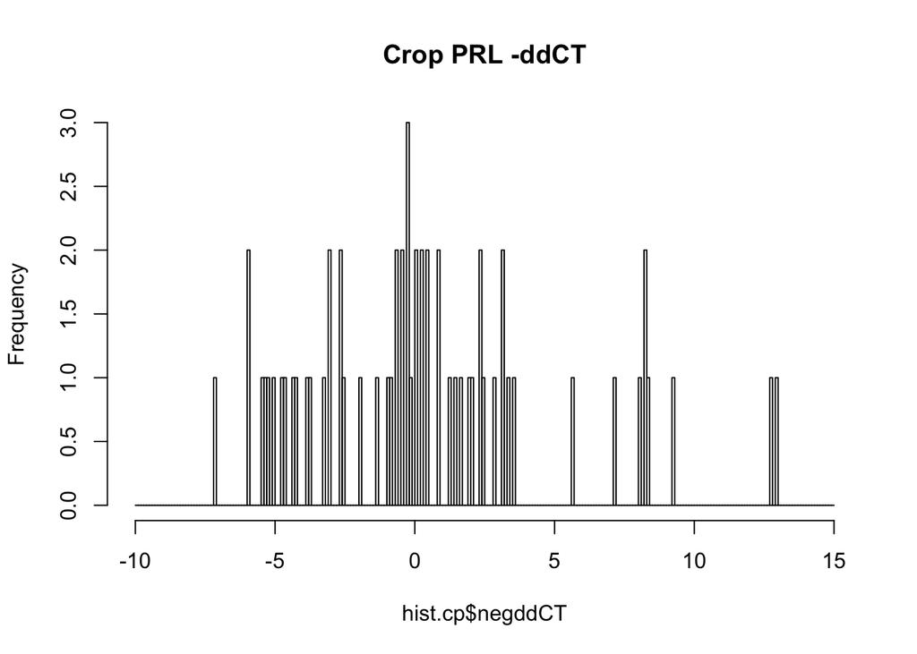

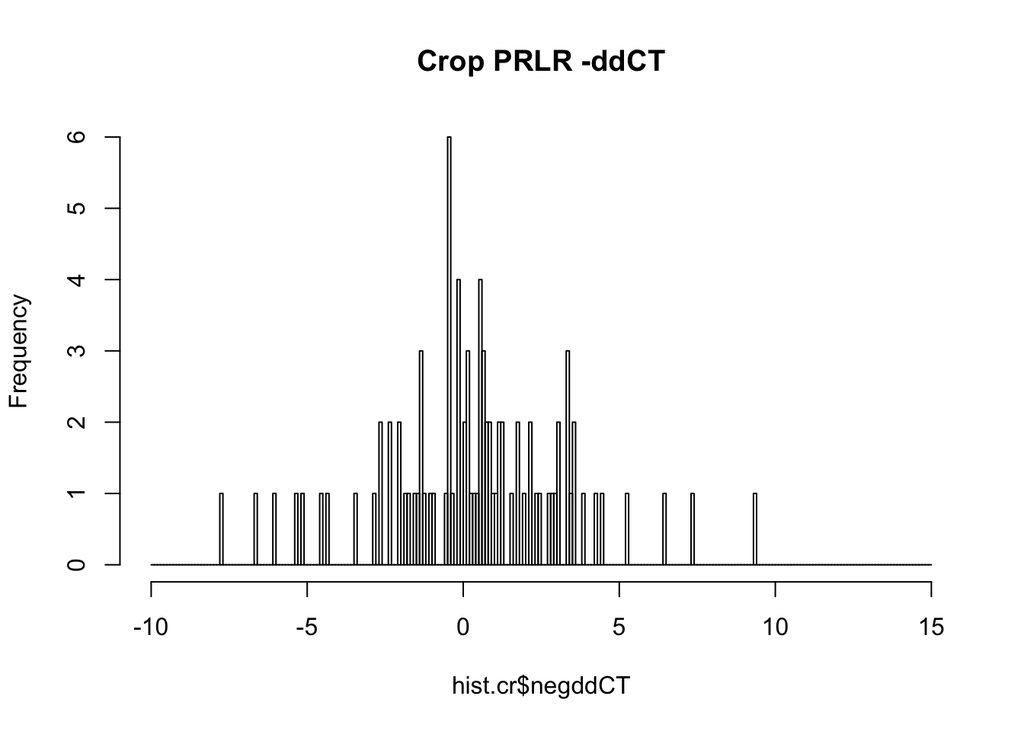

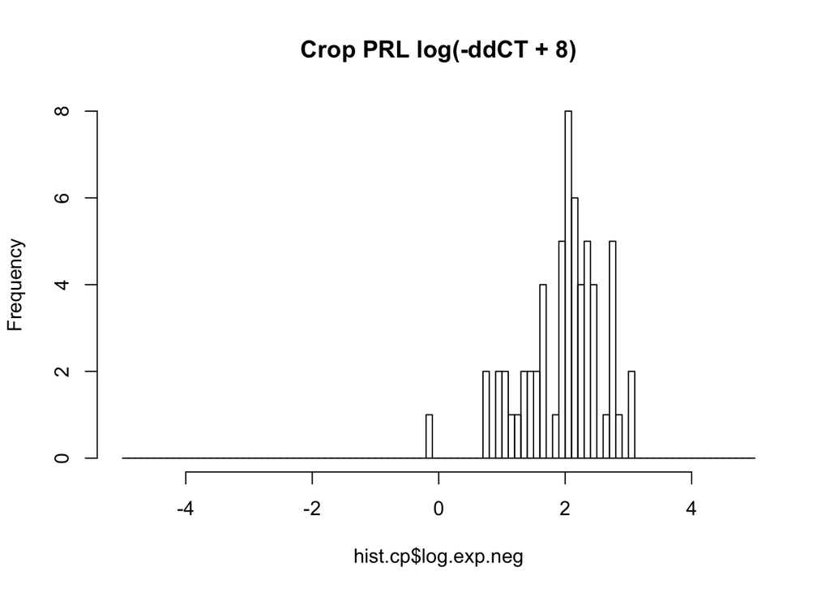

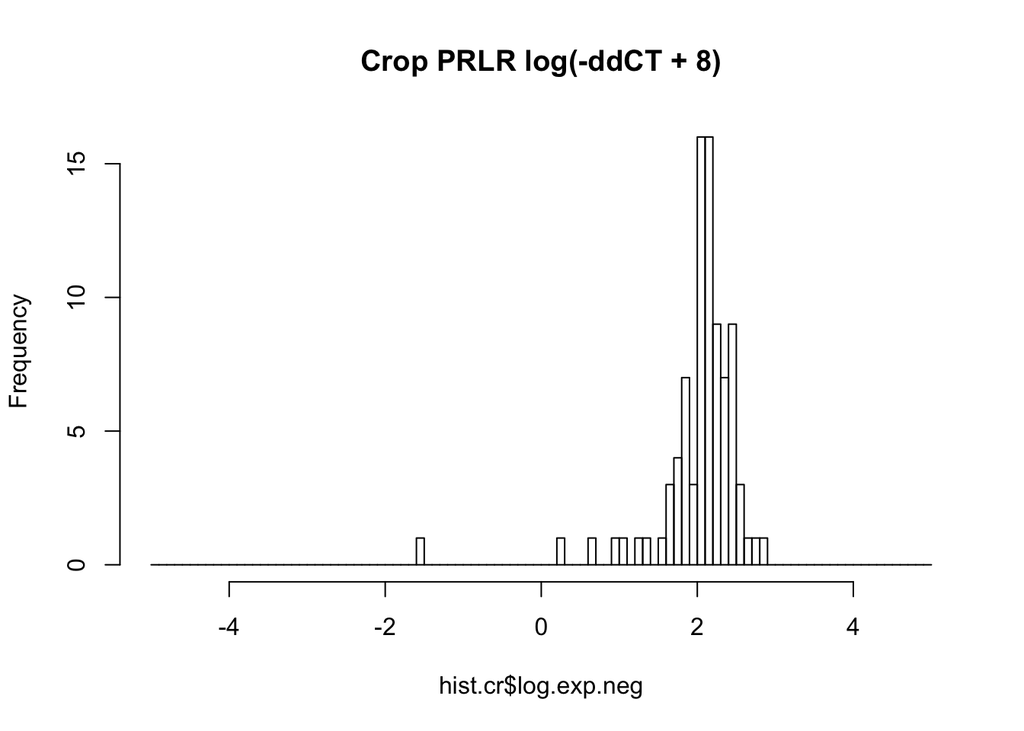

##Crop sac gene expression plots

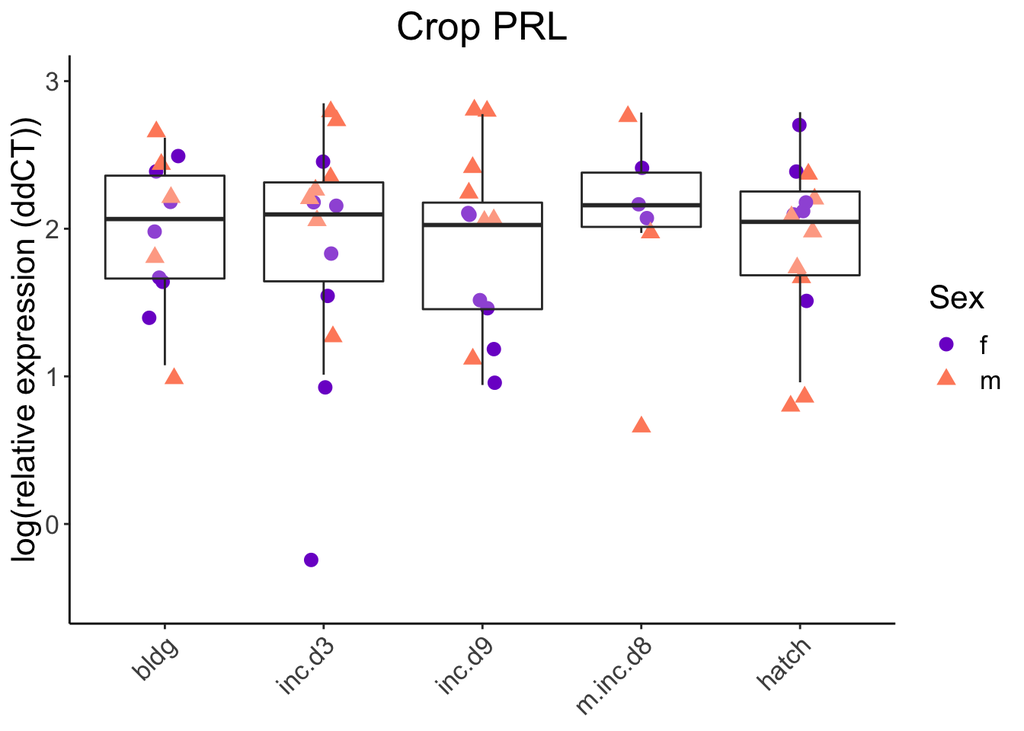

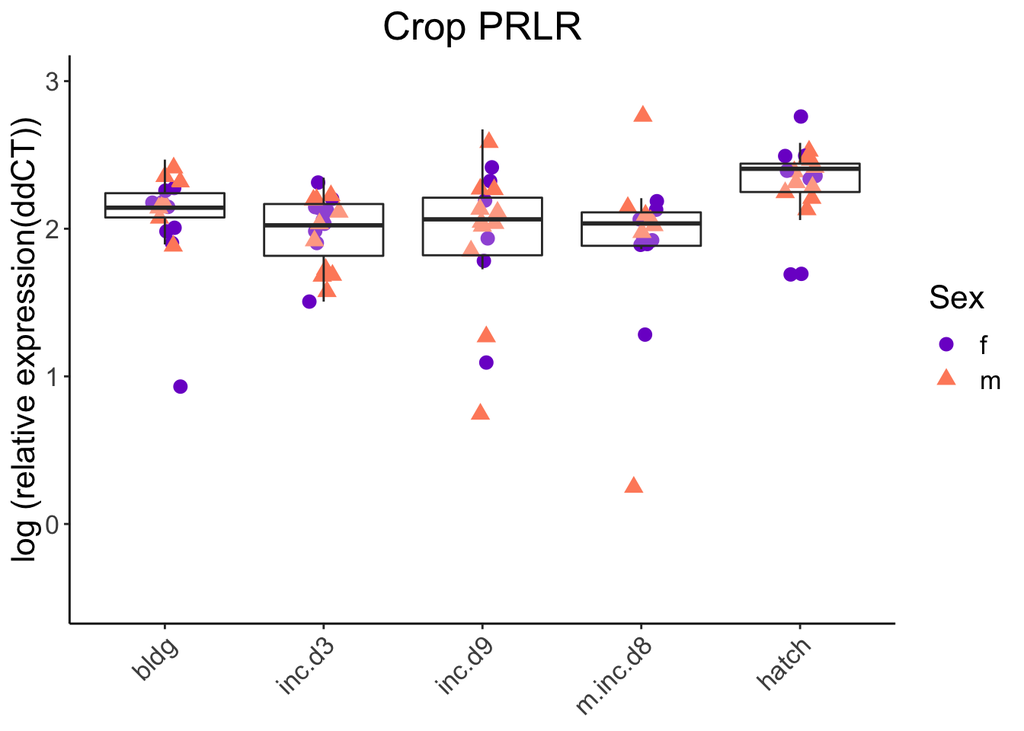

### GLM: Crop PRL

“ANOVA” : very weak trend towards an interaction, but not really anything else there. Not really anything going on in downstream analyses… Discuss mostly the fact that PRL gene expression was detectable in the crop.

```
## Analysis of Deviance Table
##
## Model: gaussian, link: identity
##
## Response: log.exp.neg
##
## Terms added sequentially (first to last)
##
##
##           Df Deviance Resid. Df Resid. Dev Pr(>Chi)
## NULL                         60     23.443
## Stage      4   0.1197        56     23.323  0.98867
## Sex        1   0.8506        55     22.473  0.13317
## Stage:Sex  4   3.2357        51     19.237  0.07254 .
## ---
## Signif. codes:  0 '***' 0.001 '**' 0.01 '*' 0.05 '.' 0.1 ' ' 1
```

```
##
## Call:
## glm(formula = log.exp.neg ~ Stage * Sex, family = "gaussian",
##     data = cp)
##
## Deviance Residuals:
##     Min       1Q   Median       3Q      Max
## -1.7026  -0.2613   0.0613   0.4779   1.1819
##
## Coefficients:
##                    Estimate Std. Error t value Pr(>|t|)
## (Intercept)          1.9373     0.2321   8.346  4.2e-11 ***
## StageInc_D3         -0.3867     0.3283  -1.178    0.244
## StageInc_D9         -0.3883     0.3417  -1.136    0.261
## StageManip_D8        0.3174     0.4238   0.749    0.457
## StageHatch           0.2111     0.3417   0.618    0.539
## Sexm                 0.1090     0.3596   0.303    0.763
## StageInc_D3:Sexm     0.5721     0.4869   1.175    0.245
## StageInc_D9:Sexm     0.6286     0.4892   1.285    0.205
## StageManip_D8:Sexm  -0.5302     0.6171  -0.859    0.394
## StageHatch:Sexm     -0.3960     0.4838  -0.819    0.417
## ---
## Signif. codes:  0 '***' 0.001 '**' 0.01 '*' 0.05 '.' 0.1 ' ' 1
##
## (Dispersion parameter for gaussian family taken to be 0.3771916)
##
##     Null deviance: 23.443  on 60  degrees of freedom
## Residual deviance: 19.237  on 51  degrees of freedom
##   (34 observations deleted due to missingness)
## AIC: 124.71
##
## Number of Fisher Scoring iterations: 2
```

```
##
## Call:
## glm(formula = log.exp.neg ~ Stage * Sex, family = "gaussian",
##     data = cp)
##
## Deviance Residuals:
##     Min       1Q   Median       3Q      Max
## -1.7026  -0.2613   0.0613   0.4779   1.1819
##
## Coefficients:
##                    Estimate Std. Error t value Pr(>|t|)
## (Intercept)          2.1485     0.2507   8.569  1.9e-11 ***
## StageBldg           -0.2111     0.3417  -0.618   0.5394
## StageInc_D3         -0.5978     0.3417  -1.750   0.0862 .
## StageInc_D9         -0.5994     0.3546  -1.691   0.0970 .
## StageManip_D8        0.1062     0.4343   0.245   0.8077
## Sexm                -0.2870     0.3237  -0.887   0.3794
## StageBldg:Sexm       0.3960     0.4838   0.819   0.4169
## StageInc_D3:Sexm     0.9682     0.4610   2.100   0.0407 *
## StageInc_D9:Sexm     1.0246     0.4635   2.211   0.0316 *
## StageManip_D8:Sexm  -0.1342     0.5969  -0.225   0.8230
## ---
## Signif. codes:  0 '***' 0.001 '**' 0.01 '*' 0.05 '.' 0.1 ' ' 1
##
## (Dispersion parameter for gaussian family taken to be 0.3771916)
##
##     Null deviance: 23.443  on 60  degrees of freedom
## Residual deviance: 19.237  on 51  degrees of freedom
##   (34 observations deleted due to missingness)
## AIC: 124.71
##
## Number of Fisher Scoring iterations: 2
```

```
##
## Call:
## glm(formula = log.exp.neg ~ Stage * Sex, family = "gaussian",
##     data = cp)
##
## Deviance Residuals:
##     Min       1Q   Median       3Q      Max
## -1.7026  -0.2613   0.0613   0.4779   1.1819
##
## Coefficients:
##                     Estimate Std. Error t value Pr(>|t|)
## (Intercept)         1.550644   0.232130   6.680 1.74e-08 ***
## StageHatch          0.597826   0.341687   1.750   0.0862 .
## StageBldg           0.386694   0.328282   1.178   0.2443
## StageInc_D9        -0.001622   0.341687  -0.005   0.9962
## StageManip_D8       0.704051   0.423810   1.661   0.1028
## Sexm                0.681135   0.328282   2.075   0.0431 *
## StageHatch:Sexm    -0.968170   0.461025  -2.100   0.0407 *
## StageBldg:Sexm     -0.572126   0.486921  -1.175   0.2455
## StageInc_D9:Sexm    0.056426   0.466672   0.121   0.9042
## StageManip_D8:Sexm -1.102365   0.599358  -1.839   0.0717 .
## ---
## Signif. codes:  0 '***' 0.001 '**' 0.01 '*' 0.05 '.' 0.1 ' ' 1
##
## (Dispersion parameter for gaussian family taken to be 0.3771916)
##
##     Null deviance: 23.443  on 60  degrees of freedom
## Residual deviance: 19.237  on 51  degrees of freedom
##   (34 observations deleted due to missingness)
## AIC: 124.71
##
## Number of Fisher Scoring iterations: 2
```

```
##
## Call:
## glm(formula = log.exp.neg ~ Stage * Sex, family = "gaussian",
##     data = cp)
##
## Deviance Residuals:
##     Min       1Q   Median       3Q      Max
## -1.7026  -0.2613   0.0613   0.4779   1.1819
##
## Coefficients:
##                  Estimate Std. Error t value Pr(>|t|)
## (Intercept)        2.2547     0.3546   6.359  5.6e-08 ***
## StageInc_D3       -0.7041     0.4238  -1.661   0.1028
## StageHatch        -0.1062     0.4343  -0.245   0.8077
## StageBldg         -0.3174     0.4238  -0.749   0.4574
## StageInc_D9       -0.7057     0.4343  -1.625   0.1103
## Sexm              -0.4212     0.5015  -0.840   0.4048
## StageInc_D3:Sexm   1.1024     0.5994   1.839   0.0717 .
## StageHatch:Sexm    0.1342     0.5969   0.225   0.8230
## StageBldg:Sexm     0.5302     0.6171   0.859   0.3942
## StageInc_D9:Sexm   1.1588     0.6012   1.927   0.0595 .
## ---
## Signif. codes:  0 '***' 0.001 '**' 0.01 '*' 0.05 '.' 0.1 ' ' 1
##
## (Dispersion parameter for gaussian family taken to be 0.3771916)
##
##     Null deviance: 23.443  on 60  degrees of freedom
## Residual deviance: 19.237  on 51  degrees of freedom
##   (34 observations deleted due to missingness)
## AIC: 124.71
##
## Number of Fisher Scoring iterations: 2
```

### PRLR Crop

“ANOVA” : weak trend towards stage Not really anything going on in downstream comparisons. **Why then did we find something significant before?**  
In previous analyses for SfN, I ran my models using -ddCT as a dependent variable, rather than log transformed -ddCT.  
With log-transformed data, the effect disappeared.

```
## Analysis of Deviance Table
##
## Model: gaussian, link: identity
##
## Response: log.exp.neg
##
## Terms added sequentially (first to last)
##
##
##           Df Deviance Resid. Df Resid. Dev Pr(>Chi)
## NULL                         87     27.303
## Stage      4  2.48731        83     24.816  0.09439 .
## Sex        1  0.09270        82     24.723  0.58682
## Stage:Sex  4  0.24016        78     24.483  0.94306
## ---
## Signif. codes:  0 '***' 0.001 '**' 0.01 '*' 0.05 '.' 0.1 ' ' 1
```

```
##
## Call:
## glm(formula = log.exp.neg ~ Stage * Sex, family = "gaussian",
##     data = cr)
##
## Deviance Residuals:
##     Min       1Q   Median       3Q      Max
## -3.2892  -0.0369   0.1035   0.2198   0.9195
##
## Coefficients:
##                    Estimate Std. Error t value Pr(>|t|)
## (Intercept)         2.00612    0.18675  10.742   <2e-16 ***
## StageInc_D3         0.04060    0.25742   0.158    0.875
## StageInc_D9        -0.06615    0.29528  -0.224    0.823
## StageManip_D8      -0.10349    0.27223  -0.380    0.705
## StageHatch          0.32043    0.26411   1.213    0.229
## Sexm               -0.26343    0.27223  -0.968    0.336
## StageInc_D3:Sexm    0.18098    0.36998   0.489    0.626
## StageInc_D9:Sexm    0.24846    0.39365   0.631    0.530
## StageManip_D8:Sexm  0.29337    0.39773   0.738    0.463
## StageHatch:Sexm     0.27602    0.37467   0.737    0.464
## ---
## Signif. codes:  0 '***' 0.001 '**' 0.01 '*' 0.05 '.' 0.1 ' ' 1
##
## (Dispersion parameter for gaussian family taken to be 0.3138829)
##
##     Null deviance: 27.303  on 87  degrees of freedom
## Residual deviance: 24.483  on 78  degrees of freedom
##   (7 observations deleted due to missingness)
## AIC: 159.15
##
## Number of Fisher Scoring iterations: 2
```

```
##
## Call:
## glm(formula = log.exp.neg ~ Stage * Sex, family = "gaussian",
##     data = cr)
##
## Deviance Residuals:
##     Min       1Q   Median       3Q      Max
## -3.2892  -0.0369   0.1035   0.2198   0.9195
##
## Coefficients:
##                    Estimate Std. Error t value Pr(>|t|)
## (Intercept)         2.32655    0.18675  12.458   <2e-16 ***
## StageBldg          -0.32043    0.26411  -1.213    0.229
## StageInc_D3        -0.27983    0.25742  -1.087    0.280
## StageInc_D9        -0.38658    0.29528  -1.309    0.194
## StageManip_D8      -0.42392    0.27223  -1.557    0.123
## Sexm                0.01259    0.25742   0.049    0.961
## StageBldg:Sexm     -0.27602    0.37467  -0.737    0.464
## StageInc_D3:Sexm   -0.09505    0.35922  -0.265    0.792
## StageInc_D9:Sexm   -0.02756    0.38355  -0.072    0.943
## StageManip_D8:Sexm  0.01734    0.38774   0.045    0.964
## ---
## Signif. codes:  0 '***' 0.001 '**' 0.01 '*' 0.05 '.' 0.1 ' ' 1
##
## (Dispersion parameter for gaussian family taken to be 0.3138829)
##
##     Null deviance: 27.303  on 87  degrees of freedom
## Residual deviance: 24.483  on 78  degrees of freedom
##   (7 observations deleted due to missingness)
## AIC: 159.15
##
## Number of Fisher Scoring iterations: 2
```

```
##
## Call:
## glm(formula = log.exp.neg ~ Stage * Sex, family = "gaussian",
##     data = cr)
##
## Deviance Residuals:
##     Min       1Q   Median       3Q      Max
## -3.2892  -0.0369   0.1035   0.2198   0.9195
##
## Coefficients:
##                    Estimate Std. Error t value Pr(>|t|)
## (Intercept)         2.04672    0.17717  11.552   <2e-16 ***
## StageHatch          0.27983    0.25742   1.087    0.280
## StageBldg          -0.04060    0.25742  -0.158    0.875
## StageInc_D9        -0.10675    0.28931  -0.369    0.713
## StageManip_D8      -0.14409    0.26575  -0.542    0.589
## Sexm               -0.08245    0.25055  -0.329    0.743
## StageHatch:Sexm     0.09505    0.35922   0.265    0.792
## StageBldg:Sexm     -0.18098    0.36998  -0.489    0.626
## StageInc_D9:Sexm    0.06748    0.37898   0.178    0.859
## StageManip_D8:Sexm  0.11239    0.38321   0.293    0.770
## ---
## Signif. codes:  0 '***' 0.001 '**' 0.01 '*' 0.05 '.' 0.1 ' ' 1
##
## (Dispersion parameter for gaussian family taken to be 0.3138829)
##
##     Null deviance: 27.303  on 87  degrees of freedom
## Residual deviance: 24.483  on 78  degrees of freedom
##   (7 observations deleted due to missingness)
## AIC: 159.15
##
## Number of Fisher Scoring iterations: 2
```

```
##
## Call:
## glm(formula = log.exp.neg ~ Stage * Sex, family = "gaussian",
##     data = cr)
##
## Deviance Residuals:
##     Min       1Q   Median       3Q      Max
## -3.2892  -0.0369   0.1035   0.2198   0.9195
##
## Coefficients:
##                  Estimate Std. Error t value Pr(>|t|)
## (Intercept)       1.90263    0.19808   9.605 7.26e-15 ***
## StageInc_D3       0.14409    0.26575   0.542    0.589
## StageHatch        0.42392    0.27223   1.557    0.123
## StageBldg         0.10349    0.27223   0.380    0.705
## StageInc_D9       0.03734    0.30257   0.123    0.902
## Sexm              0.02994    0.28996   0.103    0.918
## StageInc_D3:Sexm -0.11239    0.38321  -0.293    0.770
## StageHatch:Sexm  -0.01734    0.38774  -0.045    0.964
## StageBldg:Sexm   -0.29337    0.39773  -0.738    0.463
## StageInc_D9:Sexm -0.04491    0.40611  -0.111    0.912
## ---
## Signif. codes:  0 '***' 0.001 '**' 0.01 '*' 0.05 '.' 0.1 ' ' 1
##
## (Dispersion parameter for gaussian family taken to be 0.3138829)
##
##     Null deviance: 27.303  on 87  degrees of freedom
## Residual deviance: 24.483  on 78  degrees of freedom
##   (7 observations deleted due to missingness)
## AIC: 159.15
##
## Number of Fisher Scoring iterations: 2
```